# Project 1

# 8 Charts

Charts will appear automatically when you create a plot in the code of your R chunk. You can add a caption to the chart with the chunk option `fig.cap="My caption"`.

Here’s an example using a fuel efficiency chart:

`{r fig.cap = "**FIG 1.** MPG vs Horsepower"}')`

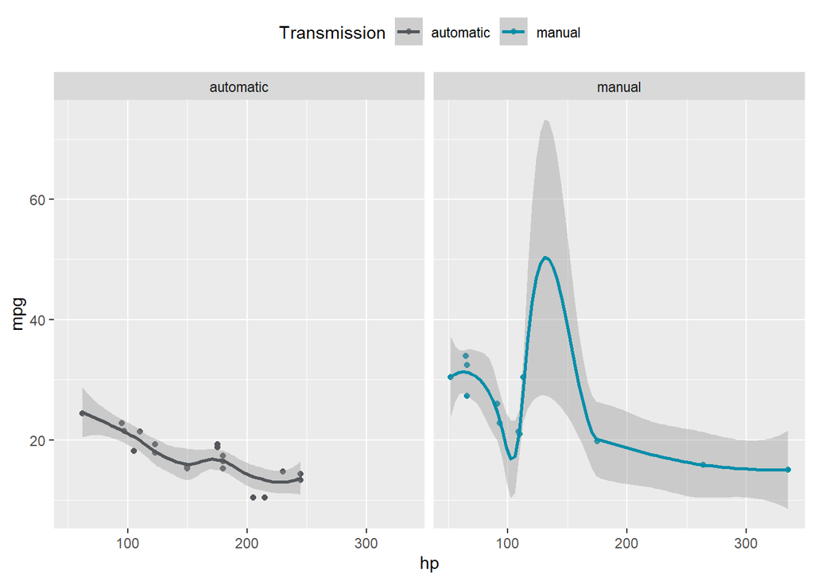

**FIG 1.** MPG vs Horsepower

```r
library(ggplot2)
library(mncolors) #remotes::install_github("tidy-mn/mncolors")

mtcars <- mtcars

mtcars$Transmission <- factor(mtcars$am,
                              labels = c('automatic',
                                         'manual'))

ggplot(mtcars, aes(hp, mpg, color = Transmission)) +
  geom_point() +
  geom_smooth() +
  scale_color_mn(palette = "accent", reverse = T) +
  facet_wrap(~Transmission) +
  theme(legend.position = 'top')
```

## Fullwidth charts

To set the size of charts, use the chunk option `out.width=` and set it to a number between **1%** (the smallest) and **100%** (the largest).

Here’s the same chart as above, but set to **out.width=“100%”**.

`{r out.width="100%", fig.cap="**FIG 2. (fullwidth)** MPG vs Horsepower"}`

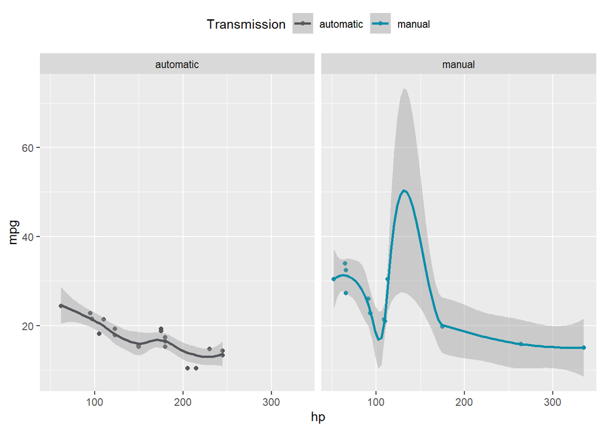

**Fig 2. (fullwidth)** MPG vs Horsepower

# 9 MN Colors

The `mncolors` package makes it easy to use the MN State brand colors in your plots. Explore the R package at https://github.com/tidy-MN/mncolors for more details and to view all available color palettes.

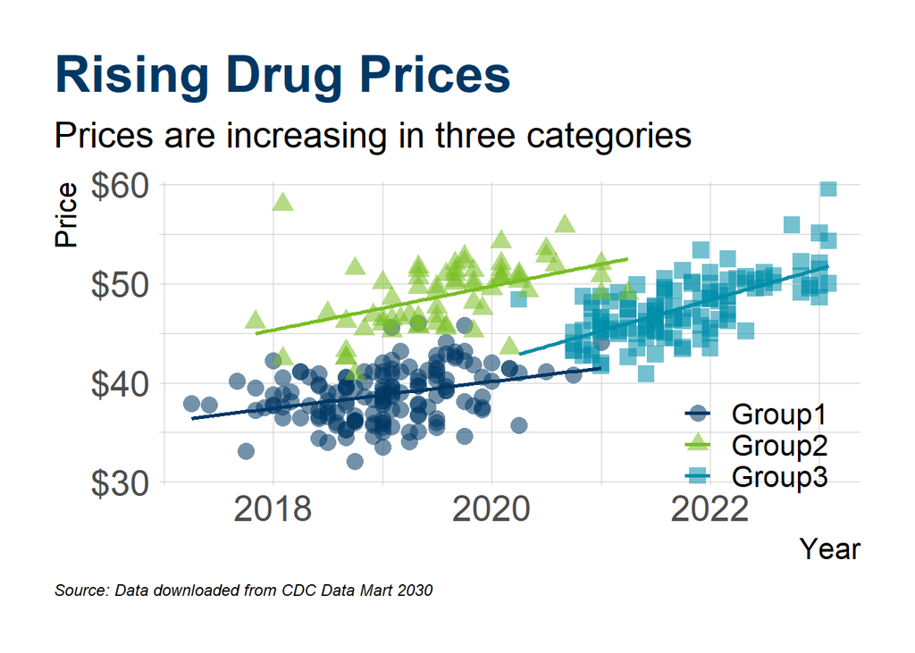

```r
#remotes::install_github("tidy-mn/mncolors")
library(mncolors)
library(tidyverse)
library(hrbrthemes)

drug_prices <- palmerpenguins::penguins %>%
               drop_na(flipper_length_mm)

drug_prices <- drug_prices %>%
               mutate(date = as.Date(paste0("20", substr(flipper_length_mm,1,2), "-", round(as.numeric(substr(flipper_length_mm,3,3))*12/10+0.6+runif(nrow(drug_prices))), "-01")))

ggplot(data = drug_prices,
       aes(x = date,
           y = bill_length_mm)) +
  geom_point(aes(color = species,
                 shape = species),
             size = 4,
             alpha = 0.55) +
  geom_smooth(method = "lm", se = F, aes(color = species)) +
  scale_color_manual(values = mncolors(7, "primary_accent")[1:3], labels = c("Group1", "Group2", "Group3")) +
  scale_shape_discrete(labels = c("Group1", "Group2", "Group3")) +
  labs(title = "Rising Drug Prices",
       subtitle = "Prices are increasing in three categories",
       x = "Year",
       y = "Price",
       color = "",
       shape = "",
       caption = "Source: Data downloaded from CDC Data Mart 2030") +
  lims(y = c(30,60)) +
  scale_y_comma(labels = scales::dollar_format(), limits = c(30,60)) +
  theme_ipsum_rc(base_size = 20) +
  theme(legend.position = c(0.85, 0.22),
        plot.title.position = "plot",
        plot.title = element_text(size = 28,
                                  family = "Arial Narrow",
                                  color = mncolors(5, "blue")[5]),
        plot.subtitle = element_text(size = 20),
        plot.caption = element_text(hjust = 0, face = "italic"),
        axis.title.x = element_text(size = 16),
        axis.title.y = element_text(size = 16),
        plot.caption.position = "plot")
```

# 10 Interactive charts

The `plotly` packages provides web charts that viewers can interact with. Any ggplot can be turned into a plotly plot by sending it to the `ggplotly()` function.

```r
library(plotly)

(ggplot(mtcars) +
  geom_point(aes(x = disp, y = mpg), color = "steelblue", size = 5)) %>%
  ggplotly()
```

[interactive chart not shown]

# 11 Tabs

You can split your content into a tabbed menu by adding `{.tabset}` after the top heading you want the tabs to appear under. Then, every sub-heading under it will appear in a tabbed menu.

For example, the following will let users select tabs to see different years of data. The top *Pick a year* heading is a level 2 (`##`) heading, so all of the level 3 (`###`) headings under it will be shown as tabs.

```markdown
## Pick a year {.tabset}

Select a year to view results.

### 2000 {-}

**2000**
This is **2000** data.

### 2010 {-}

**2010**
This is **2010** data.

### 2020 {-}

**2020**
This is **2020** data.
```

## 11.1 Pick a year

Select a year to view results.

### 2000

**2000**

This is 2000 data.

### 2010

**2010**

This is 2010 data.

### 2020

**2020**

This is 2020 data.

# 12 Equations

Surround a chunk of text with `$$` to add formatted functions and math equations.
For example, this is the equation we used to predict the migration patterns of the Pokemon.

```
### Pythagorean theorem
$$
a^2 + b^2 = c^2
$$
```

### Pythagorean theorem

> $$a^2 + b^2 = c^2$$

# 13 Maps

Leaflet maps are an easy way to add interactive maps to your report. Here’s an example displaying the polygon shapefile of tribal nations across MN.

```r
library(mpcaej) #remotes::install_github("tidy-mn/mpcaej")
library(tidyverse)
library(leaflet)
library(sf)

# Get map data ----
tribal_areas <- tribe_shapes

# Transform to lat/long coords
tribal_areas <- st_transform(tribal_areas, 4326)

# Map the polygons -----
leaflet(tribal_areas) %>%
  addProviderTiles(providers$Stamen.TonerLines,
                   options = providerTileOptions) %>%
  addProviderTiles(providers$CartoDB.Voyager,
                   options = providerTileOptions(opacity = 0.8)) %>%
  addPolygons(color        = "purple",
              weight       = 1,
              smoothFactor = 1.4,
              opacity      = 0.9,
              fillOpacity  = 0.2)
```

[interactive chart not shown]

Find more shapefiles and spatial data online in the [MN GEOCOMMONS](https://gisdata.mn.gov/).

## 13.1 Map markers

This is a map of the sites around St. Paul.

```r
sites <- read_csv(
'AqsID,Site Name,Lat,Long
270531905,Minneapolis-Harrison,44.981,-93.301
270531906,Minneapolis-Lyndale,44.946,-93.277
271377549,Duluth-Michigan St,46.771,-92.117
271231903,St. Paul-Westside,44.927,-93.067
271230871,St. Paul-Harding H.S.,44.959,-93.036
271230868,St. Paul-Downtown,44.951,-93.099
271230050,St. Paul-University Ave,44.956,-93.146
271231907,St. Paul Payne-Phalen,44.972,-93.083')

# Filter to only St. Paul sites
sites <- filter(sites, str_detect(`Site Name`, "Paul"))

# Add Markers and popup info
leaflet(sites) %>%
  addProviderTiles(providers$CartoDB) %>%
  addMarkers(popup = ~`Site Name`)
```

[interactive chart not shown]

**Circle markers**  
The circles show the `count` of Pokemon at each site.

```r
# Create example count column for map
sites$count <- c(4, 12, 44, 88, 100)

# Set the color palette
pal <- colorBin(mncolors(10, "corn"), sites$count, 4, pretty = FALSE)

# Map w/ circles colored by data column
leaflet(sites) %>%
  addProviderTiles(providers$CartoDB) %>%
  addCircleMarkers(label = ~`Site Name`,
                   color = ~pal(count),
                   opacity = 0.8) %>%
  addLegend(pal = pal,
            values = ~count,
            title = "Pokemon Count",
            #labFormat = labelFormat(prefix = "$"),
            opacity = 0.9)
```

[interactive chart not shown]

**Highlight a single site**

The site highlighted below had the most Pokemon sightings.

```r
# Use dark theme with pink highlighted site
leaflet(sites) %>%
  addProviderTiles(providers$CartoDB.DarkMatter) %>%
  addCircleMarkers(label = ~`Site Name`, color = "white") %>%
  addCircleMarkers(data   = sites[5, ],
                   color  = "hotpink",
                   radius = 15,
                   label  = ~`Site Name`,
                   labelOptions = labelOptions(noHide   = TRUE,
                                               textsize = "13px",
                                               direction = "left"))
```

[interactive chart not shown]

# 14 Collapsible content

To hide a long list or table you can use `<details> and <summary>` to create hidden drop-down content. Adding the following creates a drop-down window in your document that starts collapsed, but expands when the reader selects it.

```
<details>
<summary> **Click to see the secret list** </summary>

This is a hidden list inside a collapsible menu.

- fish
- bird
- toad
- stone

</details>
```

**Click to see the secret list**

This is a hidden list inside a collapsible menu.

- fish
- bird
- toad
- stone

# 15 Footnotes

You can add footnotes with the `^[Footnote]` syntax.

This Markdown adds two footnotes to R markdown references. The footnote’s text inside the brackets appears at the bottom of the page.

```
Learn more at **RStudio's Get Started Guide**^[RStudio's Get Started Guide-https://rmarkdown.rstudio.com/index.html] and from the online book **R Markdown: The Definitive Guide**^[R Markdown: The Definitive Guide-https://bookdown.org/yihui/rmarkdown/].
```

> Learn more at **RStudio’s Get Started Guide**[^1] and from the online book **R Markdown: The Definitive Guide**[^2].

# 16 References

R Core Team. 2022. *R: A Language and Environment for Statistical Computing*. Vienna, Austria: R Foundation for Statistical Computing. https://www.R-project.org/.

Wickham, Hadley, Romain François, Lionel Henry, Kirill Müller, and Davis Vaughan. 2023. *Dplyr: A Grammar of Data Manipulation*. https://CRAN.R-project.org/package=dplyr.

[^1]: RStudio’s Get Started Guide-https://rmarkdown.rstudio.com/index.html
[^2]: R Markdown: The Definitive Guide-https://bookdown.org/yihui/rmarkdown/